# Investigation of multi-trait EBMF program correspondence

This vignette extends the single-trait investigation (`investigation-univariate-analysis.html`) to **multiple traits**, and asks one question: **which programs are shared between traits, and do they push the two traits the same way or opposite ways?**

EBMF programs are discovered independently for each target trait, so each trait’s architecture is described in its own terms first. Every cross-trait pair of programs is then scored by **loading-weighted locus concordance**: across the loci both traits carry, how much of the same signal do the two programs load on, and with what sign. No hard locus cutoff is applied — every shared locus contributes in proportion to how strongly both programs load on it, so the evidence grows with the amount of shared architecture rather than with how tightly a handful of loci happen to align. A permutation null calibrated per program turns that into significance, linked programs are joined into **multi-trait families**, and each link is then given a direction two independent ways: the sign of the concordance, and `module_rg()`, the correlation of the two traits’ own SNP effects across the module’s loci.

Traits are supplied as an array in `params$trait_ids`. We use **Body mass index** (trait id 1992), **Height** (trait id 1993).

Active run parameters

| api | trait_ids | trait_subset | min_snp_signals | min_module_size | compress_method | compress_scale | include_trans | similarity_threshold | ebmf_lfsr_threshold | ebmf_magnitude_threshold | ebmf_prior | ebmf_backfit | min_mean_internal | min_connectedness | n_null | n_rep | n_perm | fdr_threshold | associations |
| --- | --- | --- | --- | --- | --- | --- | --- | --- | --- | --- | --- | --- | --- | --- | --- | --- | --- | --- | --- |
| local | 1992, 1993 | phenotypic | 2 | 3 | asinh | 5 | FALSE | 0.2 | 0.02 | 0.5 | point_laplace | TRUE | 0.3 | 0.5 | 5 | 2 | 3000 | 0.05 | coloc |

Target traits compared

| trait_id | trait_name |
| --- | --- |
| 1992 | Body mass index |
| 1993 | Height |

## Step 1: Univariate EBMF per trait

The existing single-trait pipeline is run independently for each target trait: `run_univariate_clustering()` (EBMF) followed by `summarise_ebmf_programs()`. Programs are kept when they pass the validation filters (`status == "valid"`). Each program’s posterior-mean SNP loadings (`F_pm`), lFSR, and high-confidence SNP membership are then extracted, with loadings sign-oriented to the target trait (see `extract_program_loadings()`).

Per-trait EBMF programs (valid = passes size, internal coherence, stability, and redundancy filters; stability is not checked when n_rep = 0)

| trait_id | trait_name | n_programs | n_valid | n_valid_snps |
| --- | --- | --- | --- | --- |
| 1992 | Body mass index | 50 | 14 | 1203 |
| 1993 | Height | 50 | 12 | 1454 |

Valid programs only – everything downstream uses these. `n_snps_filtered` is how many SNPs pass the program’s lFSR/magnitude gate; `mean_internal_similarity` and `connectedness` say how tightly those SNPs cohere on the SNP-similarity graph; `factor_strength` is the share of matrix signal the factor carries (it scales with program size, so small programs are not worse for having a small value); `posterior_evidence` is the median -log10(lFSR) of its members. Programs that failed validation are not shown – see the univariate vignette for that diagnostic view.

| trait_name | program | n_snps_filtered | mean_internal_similarity | connectedness | factor_strength | posterior_evidence |
| --- | --- | --- | --- | --- | --- | --- |
| Body mass index | 1 | 423 | 0.546 | 0.936 | 0.530 | 50.00 |
| Body mass index | 4 | 134 | 0.385 | 0.760 | 0.030 | 10.63 |
| Body mass index | 24 | 109 | 0.354 | 0.706 | 0.011 | 4.24 |
| Body mass index | 8 | 106 | 0.428 | 0.831 | 0.025 | 7.81 |
| Body mass index | 7 | 98 | 0.454 | 0.877 | 0.016 | 13.76 |
| Body mass index | 17 | 96 | 0.401 | 0.806 | 0.009 | 4.51 |
| Body mass index | 40 | 64 | 0.534 | 0.938 | 0.009 | 3.96 |
| Body mass index | 39 | 46 | 0.522 | 0.851 | 0.008 | 5.80 |
| Body mass index | 35 | 38 | 0.374 | 0.740 | 0.005 | 10.40 |
| Body mass index | 42 | 31 | 0.341 | 0.652 | 0.006 | 7.44 |
| Body mass index | 20 | 28 | 0.427 | 0.812 | 0.001 | 6.50 |
| Body mass index | 22 | 19 | 0.416 | 0.930 | 0.006 | 14.27 |
| Body mass index | 46 | 7 | 0.377 | 0.762 | 0.002 | 10.67 |
| Body mass index | 21 | 4 | 0.392 | 0.833 | 0.000 | 5.57 |
| Height | 1 | 399 | 0.602 | 0.980 | 0.239 | 50.00 |
| Height | 2 | 223 | 0.582 | 0.975 | 0.023 | 50.00 |
| Height | 9 | 173 | 0.447 | 0.892 | 0.024 | 20.06 |
| Height | 18 | 129 | 0.476 | 0.904 | 0.023 | 12.72 |
| Height | 33 | 116 | 0.501 | 0.898 | 0.017 | 14.35 |
| Height | 6 | 97 | 0.362 | 0.753 | 0.024 | 50.00 |
| Height | 19 | 83 | 0.414 | 0.775 | 0.004 | 8.93 |
| Height | 27 | 68 | 0.400 | 0.756 | 0.007 | 13.30 |
| Height | 30 | 59 | 0.456 | 0.853 | 0.006 | 12.78 |
| Height | 17 | 43 | 0.392 | 0.788 | 0.002 | 7.63 |
| Height | 48 | 41 | 0.398 | 0.650 | 0.004 | 9.44 |
| Height | 12 | 23 | 0.496 | 0.850 | 0.001 | 12.55 |

## Step 2: Common locus universe

Programs are compared at the level of the **`coloc_group_id`** (the shared fine-mapped locus) rather than the exact `variant_id`, because each trait carries a single candidate SNP per coloc group. The table below counts the candidate loci per trait and how many coloc groups the traits share.

Candidate locus (coloc group) universe per trait (across valid programs)

| trait_id | trait_name | n_programs | n_loci_any | n_high_conf_loci |
| --- | --- | --- | --- | --- |
| 1992 | Body mass index | 14 | 970 | 641 |
| 1993 | Height | 12 | 2559 | 874 |

Shared coloc-group universe across traits

| n_loci_any | n_loci_shared_by_traits | max_traits_per_locus |
| --- | --- | --- |
| 3456 | 73 | 2 |

## Step 3: Loading-weighted locus concordance

Every cross-trait pair of programs is scored on the **locus axis**: the loci that both traits carry a loading for (`n_loci_axis`). No lFSR or magnitude threshold is applied — each locus contributes in proportion to how strongly it loads in *both* programs:

$$\text{locus\_concordance} = \sum_l w_l
\, f_a(l) \, f_b(l), \qquad
w_l = (1 - \text{lfsr}_a(l))(1 - \text{lfsr}_b(l))$$

Two programs that load on many of the same loci, in the same direction, score highly; a locus that matters to only one of them contributes almost nothing on its own. Because `extract_program_loadings()` orients each program so its own target trait loads positively, the **sign** is meaningful: positive means the two programs rise and fall together, negative means they oppose.

Scale of the comparison. `n_loci_axis` is how many loci each pair is scored on (the two traits’ shared coloc-group universe). `n_programs_significant` counts programs whose best partner beats what they would have found by chance. The two link tiers are explained in Step 4.

| n_programs | n_cross_trait_pairs | n_loci_axis | n_programs_significant | n_primary_links | n_candidate_links | n_concordant | n_antagonistic |
| --- | --- | --- | --- | --- | --- | --- | --- |
| 26 | 168 | 73 | 13 | 4 | 10 | 9 | 5 |

## Step 4: What counts as a link

A pair is called a link in one of two tiers.

- **`primary`** — the two programs are each other’s *best* partner, **and** both are individually significant. Program-level significance comes from a max-statistic permutation null: it asks whether a program’s best partner is better than the best partner it would have found by chance, so it is not inflated by searching over many candidates. This is the strict, one-to-one reading and is what `shared = TRUE` marks.
- **`candidate`** — the pair’s own `q_concordance` clears the FDR threshold but it is not a reciprocal best match. These are worth looking at because one program can genuinely correspond to two in the other trait (EBMF often splits one biological module into several factors), but they are not calibrated for the search over partners, so treat them as leads rather than conclusions.

The columns to read, and what each is telling you:

Linked program pairs, primary tier first then candidates, each ordered by |concordance_z|. Read `n_eff_loci` alongside `concordance_z`: a large z resting on 2-3 effective loci is a thin result.

| column | what it means |
| --- | --- |
| `concordance_z` | the headline statistic: how far the pair’s shared loading is from its own permutation null, in SD units. Sign gives the direction. This is what ranks and links. |
| `n_loci_shared` | how many *high-confidence* loci the two programs both claim. Context only — it no longer gates anything. |
| `n_eff_loci` | how many loci are effectively carrying the score. A value near 2–3 means a couple of loci are doing all the work, however large `concordance_z` looks. |
| `locus_concordance` | the raw weighted sum. Scales with both the number of co-loading loci and their magnitude, so it is not comparable across pairs on its own. |
| `cosine_loci` | the same quantity fully normalised. Deliberately *not* used to decide links: being scale-free it cannot tell a pair sharing 3 loci from one sharing 30. Useful as a “how tight is the alignment” readout… |
| `q_concordance` | BH-adjusted pair-level p. Defines the `candidate` tier; it does **not** decide `primary` links. |

| program_id_a | program_id_b | link_tier | direction | concordance_z | q_concordance | n_loci_shared | n_eff_loci | locus_concordance | cosine_loci |
| --- | --- | --- | --- | --- | --- | --- | --- | --- | --- |
| 1992:39 | 1993:27 | primary | antagonistic | -7.61 | 0.0056 | 5 | 3.5 | -7.32 | -0.973 |
| 1992:42 | 1993:30 | primary | antagonistic | -6.61 | 0.0056 | 1 | 1.4 | -5.64 | -0.782 |
| 1992:1 | 1993:1 | primary | concordant | 6.11 | 0.0056 | 28 | 18.7 | 44.66 | 0.829 |
| 1992:40 | 1993:33 | primary | concordant | 4.20 | 0.0056 | 4 | 5.7 | 1.43 | 0.535 |
| 1992:39 | 1993:1 | candidate | antagonistic | -5.40 | 0.0056 | 7 | 5.9 | -15.35 | -0.909 |
| 1992:1 | 1993:6 | candidate | concordant | 4.97 | 0.0056 | 34 | 21.4 | 46.55 | 0.650 |
| 1992:39 | 1993:6 | candidate | antagonistic | -4.55 | 0.0056 | 7 | 5.5 | -17.76 | -0.888 |
| 1992:39 | 1993:30 | candidate | antagonistic | -4.50 | 0.0431 | 2 | 2.0 | -3.83 | -0.942 |
| 1992:1 | 1993:27 | candidate | concordant | 4.34 | 0.0056 | 5 | 3.6 | 10.19 | 0.892 |
| 1992:4 | 1993:33 | candidate | concordant | 4.03 | 0.0056 | 4 | 5.3 | 3.40 | 0.826 |
| 1992:4 | 1993:19 | candidate | concordant | 3.54 | 0.0056 | 0 | 6.9 | 2.10 | 0.778 |
| 1992:42 | 1993:12 | candidate | concordant | 3.37 | 0.0204 | 1 | 1.4 | 2.38 | 0.947 |
| 1992:4 | 1993:2 | candidate | concordant | 2.78 | 0.0327 | 1 | 13.4 | 4.61 | 0.482 |
| 1992:40 | 1993:2 | candidate | concordant | 2.59 | 0.0440 | 1 | 4.1 | 1.69 | 0.834 |

## Step 5: Program families

Programs are nodes and **primary** links are edges. Because primary links are reciprocal best matches, families are one-to-one correspondences rather than transitive chains that collapse everything into one component. A program with no primary link forms its own family of one.

```
#>
#>
#> Table: Programs joined into multi-trait families. Only families spanning more than one trait are shown; single-program families are omitted.
#>
#> |program_id |trait_id |trait_name      |family    |
#> |:----------|:--------|:---------------|:---------|
#> |1992:1     |1992     |Body mass index |family_1  |
#> |1993:1     |1993     |Height          |family_1  |
#> |1992:39    |1992     |Body mass index |family_11 |
#> |1993:27    |1993     |Height          |family_11 |
#> |1992:40    |1992     |Body mass index |family_12 |
#> |1993:33    |1993     |Height          |family_12 |
#> |1992:42    |1992     |Body mass index |family_13 |
#> |1993:30    |1993     |Height          |family_13 |
#>
#>
#> Table: Per-family metrics. `n_concordant` / `n_antagonistic` count edges by the sign of `concordance_z`, so a family carrying both is one whose programs do not agree on direction.
#>
#> |family    | n_programs| n_traits| n_edges| mean_concordance_z| mean_locus_concordance| n_concordant| n_antagonistic| n_shared_loci|
#> |:---------|----------:|--------:|-------:|------------------:|----------------------:|------------:|--------------:|-------------:|
#> |family_1  |          2|        2|       1|               6.11|                  44.66|            1|              0|            28|
#> |family_11 |          2|        2|       1|              -7.61|                  -7.32|            0|              1|             5|
#> |family_12 |          2|        2|       1|               4.20|                   1.43|            1|              0|             4|
#> |family_13 |          2|        2|       1|              -6.61|                  -5.64|            0|              1|             1|
```

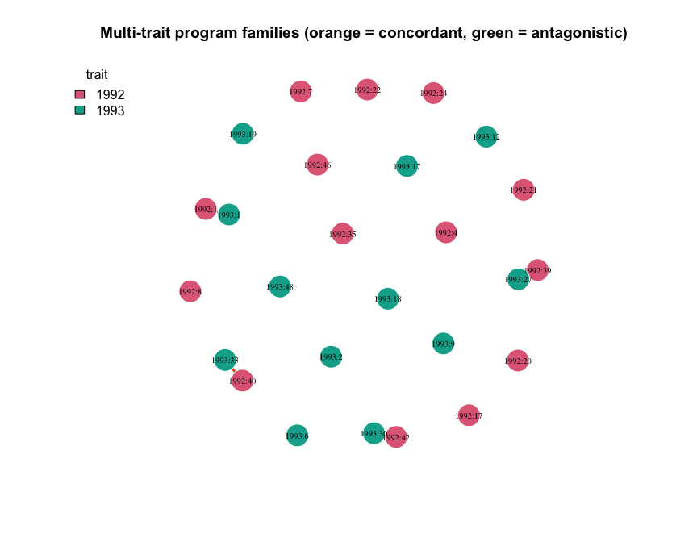

## Step 6: Direction of the shared effect (module rg)

`concordance_z` says whether two programs’ *loading patterns* line up. It does not say whether the alleles involved push the two traits the same way. `module_rg()` answers that directly: across the module’s loci it correlates the two traits’ **own** SNP effects, weighting each locus by how strongly the module loads on it and by the precision of the two estimates.

- **`rg` > 0** — alleles that raise trait A also raise trait B across this module.
- **`rg` < 0** — they oppose: the module is antagonistic between the two traits.
- **`rg_ci_lower` / `rg_ci_upper`** — percentile bootstrap over loci. **If the interval spans 0, the direction is not established**, whatever the point estimate says.
- **`n_allele_mismatch`** — loci dropped because the two traits’ `variant_id` did not agree, which would make the sign meaningless. Should be 0.

`rg_direction` and `direction` need not agree: the first is about observed allele effects, the second about latent factor structure. Where they disagree, `rg` with its CI is the more directly interpretable claim.

Cross-trait effect correlation across each linked module’s loci. `ci_excludes_zero` is the column to filter on before believing a direction.

| program_id_a | program_id_b | trait_id_a | trait_id_b | link_tier | rg | rg_ci_lower | rg_ci_upper | n_loci_rg | n_allele_mismatch | rg_direction | ci_excludes_zero |
| --- | --- | --- | --- | --- | --- | --- | --- | --- | --- | --- | --- |
| 1992:39 | 1993:27 | 1992 | 1993 | primary | 0.914 | -0.655 | 1.000 | 73 | 0 | concordant | FALSE |
| 1992:1 | 1993:1 | 1992 | 1993 | primary | 0.756 | 0.563 | 0.878 | 73 | 0 | concordant | TRUE |
| 1992:40 | 1993:33 | 1992 | 1993 | primary | -0.680 | -0.998 | 0.530 | 73 | 0 | antagonistic | FALSE |
| 1992:42 | 1993:30 | 1992 | 1993 | primary | 0.602 | -0.996 | 1.000 | 73 | 0 | concordant | FALSE |
| 1992:39 | 1993:30 | 1992 | 1993 | candidate | 1.000 | -0.254 | 1.000 | 73 | 0 | concordant | FALSE |
| 1992:1 | 1993:27 | 1992 | 1993 | candidate | 0.931 | -0.501 | 0.999 | 73 | 0 | concordant | FALSE |
| 1992:39 | 1993:6 | 1992 | 1993 | candidate | 0.869 | 0.707 | 0.976 | 73 | 0 | concordant | TRUE |
| 1992:39 | 1993:1 | 1992 | 1993 | candidate | 0.860 | 0.767 | 0.978 | 73 | 0 | concordant | TRUE |
| 1992:40 | 1993:2 | 1992 | 1993 | candidate | -0.793 | -0.990 | 0.654 | 73 | 0 | antagonistic | FALSE |
| 1992:4 | 1993:33 | 1992 | 1993 | candidate | -0.743 | -0.975 | 0.402 | 73 | 0 | antagonistic | FALSE |
| 1992:42 | 1993:12 | 1992 | 1993 | candidate | -0.677 | -0.995 | 0.998 | 73 | 0 | antagonistic | FALSE |
| 1992:4 | 1993:2 | 1992 | 1993 | candidate | -0.618 | -0.812 | -0.107 | 73 | 0 | antagonistic | TRUE |
| 1992:1 | 1993:6 | 1992 | 1993 | candidate | 0.604 | 0.268 | 0.783 | 73 | 0 | concordant | TRUE |
| 1992:4 | 1993:19 | 1992 | 1993 | candidate | 0.361 | -0.775 | 0.967 | 73 | 0 | concordant | FALSE |

## Step 7: Do linked programs recover the same biology?

Annotations play no part in forming a link, so agreement here is **independent corroboration** rather than a restatement of the same evidence. Each program’s high-confidence SNPs are enriched separately, against its own trait’s full candidate universe, for trait categories and for tissues.

Read it as: if the two sides of a pair independently surface the same category or tissue, the link has support beyond the loading geometry that created it. If they surface nothing in common, the link rests on the loci alone.

One caveat: a program holding a large share of its trait’s SNPs is being compared against a background that is largely itself, so “none” for a dominant program is expected rather than informative.

Trait-category and tissue enrichment of each side of a linked pair, computed independently per trait against that trait’s own SNP universe. Matching entries between the `_a` and `_b` columns are held-out support for the link.

| pair | tier | direction | categories_a | categories_b | tissues_a | tissues_b |
| --- | --- | --- | --- | --- | --- | --- |
| 1992:39 ~ 1993:27 | primary | antagonistic | Metabolic Disease (FDR=0.0014) Reproductive Measures (FDR=0.0027) | Disease Of Circulatory System (FDR=0.002) Metabolic Disease (FDR=0.0024) | none | none |
| 1992:42 ~ 1993:30 | primary | antagonistic | none | Nervous System Disorders (FDR=0.00019) Neurological Disease (FDR=0.0048) Disease Of Eye And Adnexa (FDR=0.0067) Disease Of Musculoskeletal System And Connective Tissue (FDR=0.008) | none | none |
| 1992:1 ~ 1993:1 | primary | concordant | none | Physiological Measures (FDR=2.7e-11) Psychiatric Measures (FDR=7.7e-06) Nervous System Disorders (FDR=6.4e-05) Disease Of Circulatory System (FDR=6.4e-05) | Cells EBV transformed lymphocytes (FDR=0) Whole Blood (FDR=0.0072) | none |
| 1992:40 ~ 1993:33 | primary | concordant | none | none | none | none |
| 1992:39 ~ 1993:1 | candidate | antagonistic | Metabolic Disease (FDR=0.0014) Reproductive Measures (FDR=0.0027) | Physiological Measures (FDR=2.7e-11) Psychiatric Measures (FDR=7.7e-06) Nervous System Disorders (FDR=6.4e-05) Disease Of Circulatory System (FDR=6.4e-05) | none | none |
| 1992:1 ~ 1993:6 | candidate | concordant | none | Metabolic Disease (FDR=0.016) Behavioural Measures (FDR=0.016) Socioeconomic Measures (FDR=0.018) Disease Of Skin And Subcutaneous Tissue (FDR=0.033) | Cells EBV transformed lymphocytes (FDR=0) Whole Blood (FDR=0.0072) | none |
| 1992:39 ~ 1993:6 | candidate | antagonistic | Metabolic Disease (FDR=0.0014) Reproductive Measures (FDR=0.0027) | Metabolic Disease (FDR=0.016) Behavioural Measures (FDR=0.016) Socioeconomic Measures (FDR=0.018) Disease Of Skin And Subcutaneous Tissue (FDR=0.033) | none | none |
| 1992:39 ~ 1993:30 | candidate | antagonistic | Metabolic Disease (FDR=0.0014) Reproductive Measures (FDR=0.0027) | Nervous System Disorders (FDR=0.00019) Neurological Disease (FDR=0.0048) Disease Of Eye And Adnexa (FDR=0.0067) Disease Of Musculoskeletal System And Connective Tissue (FDR=0.008) | none | none |
| 1992:1 ~ 1993:27 | candidate | concordant | none | Disease Of Circulatory System (FDR=0.002) Metabolic Disease (FDR=0.0024) | Cells EBV transformed lymphocytes (FDR=0) Whole Blood (FDR=0.0072) | none |
| 1992:4 ~ 1993:33 | candidate | concordant | Metabolic Disease (FDR=6.6e-05) Reproductive Measures (FDR=0.00076) Disease Of Circulatory System (FDR=0.01) Neoplasm (FDR=0.014) | none | none | none |
| 1992:4 ~ 1993:19 | candidate | concordant | Metabolic Disease (FDR=6.6e-05) Reproductive Measures (FDR=0.00076) Disease Of Circulatory System (FDR=0.01) Neoplasm (FDR=0.014) | Physiological Measures (FDR=0.035) | none | none |
| 1992:42 ~ 1993:12 | candidate | concordant | none | none | none | none |
| 1992:4 ~ 1993:2 | candidate | concordant | Metabolic Disease (FDR=6.6e-05) Reproductive Measures (FDR=0.00076) Disease Of Circulatory System (FDR=0.01) Neoplasm (FDR=0.014) | none | none | none |
| 1992:40 ~ 1993:2 | candidate | concordant | none | none | none | none |

## Interpretation notes

- **Direction is anchored, not absolute.** EBMF factor signs are not identifiable and are arbitrary across independent fits. `extract_program_loadings()` reflects both `F_pm` and `L_pm` so each program’s target-trait loading is positive, which is what makes a positive `concordance_z` readable as “target-aligned”.
- **Evidence scales with shared loading, not with tightness.** The statistic is deliberately covariance-like. A fully normalised version (`cosine_loci`) cannot distinguish a pair sharing 3 loci from one sharing 30, which is why it is reported but not used to decide links.
- **Always read `n_eff_loci`.** A large `concordance_z` resting on 2–3 effective loci is a thin result, and the permutation null cannot tell you that on its own.
- **Two tiers, two strengths of claim.** `primary` is calibrated for the search over partners and is one-to-one. `candidate` is not, and exists because EBMF factor splitting means a single module can appear as several programs.
- **Sample overlap is not corrected.** When the two target traits come from the same cohort, their effect estimates share participants, which biases `module_rg` away from the null. Treat rg magnitudes from same-cohort pairs as optimistic.
- **Winner’s curse.** Loci enter each trait’s universe only by clearing that trait’s own significance and fine-mapping bar, so the shared set is doubly selected and effect sizes are inflated.
- **Restricted to valid programs.** Only programs passing the per-trait validation filters are compared; Step 1 shows exactly which survived.